# Real-world Data Wrangling

In this project, you will apply the skills you acquired in the course to gather and wrangle real-world data with two datasets of your choice.

You will retrieve and extract the data, assess the data programmatically and visually, accross elements of data quality and structure, and implement a cleaning strategy for the data. You will then store the updated data into your selected database/data store, combine the data, and answer a research question with the datasets.

Throughout the process, you are expected to:

1. Explain your decisions towards methods used for gathering, assessing, cleaning, storing, and answering the research question
2. Write code comments so your code is more readable

Before you start, install the some of the required packages.

```python
!python -m pip install kaggle==1.6.12
```

```python
!pip install --target=/workspace ucimlrepo numpy==1.24.3
```

[output not shown]

```python
!pip install kaggle
```

**Note:** Restart the kernel to use updated package(s).

## 1. Gather data

In this section, you will extract data using two different data gathering methods and combine the data. Use at least two different types of data-gathering methods.

### **1.1.** Problem Statement

Finding the right datasets can be time-consuming. Here we provide you with a list of websites to start with. But we encourage you to explore more websites and find the data that interests you.

- Google Dataset Search https://datasetsearch.research.google.com/
- The U.S. Government’s open data https://data.gov/
- UCI Machine Learning Repository https://archive.ics.uci.edu/ml/index.php

### **1.2.** Gather at least two datasets using two different data gathering methods

List of data gathering methods:

- Download data manually
- Programmatically downloading files
- Gather data by accessing APIs
- Gather and extract data from HTML files using BeautifulSoup
- Extract data from a SQL database

Each dataset must have at least two variables, and have greater than 500 data samples within each dataset.

For each dataset, briefly describe why you picked the dataset and the gathering method (2-3 full sentences), including the names and significance of the variables in the dataset. Show your work (e.g., if using an API to download the data, please include a snippet of your code).

Load the dataset programmtically into this notebook.

#### **Dataset 1**

Type: CSV File.

Method: the data was gathered using the manual downloading method from kaggle.

Dataset variables:

- App: name of the application.
- Category: wether the app is game, edu,etc... related
- Rating: avg given by users
- Reviews: tot number of user reviews
- size: size of the app
- installs: nuember of time the app have been installed
- type: wehter the app is free or not.
- price: if the app is paid, this is where the price is stored
- content rating: age group
- genres: genres of the apps
- last updated: date when app was last ud
- current ver: current version
- andriod ver: andriod version required to run the certain app.

```python
#FILL IN 1st data gathering and loading method

import pandas as pd


df1 = pd.read_csv("googleplaystore.csv")

df1.head()
```

|  | App | Category | Rating | Reviews | Size | Installs | Type | Price | Content Rating | Genres | Last Updated | Current Ver | Android Ver |
| --- | --- | --- | --- | --- | --- | --- | --- | --- | --- | --- | --- | --- | --- |
| 0 | Photo Editor & Candy Camera & Grid & ScrapBook | ART_AND_DESIGN | 4.1 | 159 | 19M | 10,000+ | Free | 0 | Everyone | Art & Design | January 7, 2018 | 1.0.0 | 4.0.3 and up |
| 1 | Coloring book moana | ART_AND_DESIGN | 3.9 | 967 | 14M | 500,000+ | Free | 0 | Everyone | Art & Design;Pretend Play | January 15, 2018 | 2.0.0 | 4.0.3 and up |
| 2 | U Launcher Lite – FREE Live Cool Themes, Hide ... | ART_AND_DESIGN | 4.7 | 87510 | 8.7M | 5,000,000+ | Free | 0 | Everyone | Art & Design | August 1, 2018 | 1.2.4 | 4.0.3 and up |
| 3 | Sketch - Draw & Paint | ART_AND_DESIGN | 4.5 | 215644 | 25M | 50,000,000+ | Free | 0 | Teen | Art & Design | June 8, 2018 | Varies with device | 4.2 and up |
| 4 | Pixel Draw - Number Art Coloring Book | ART_AND_DESIGN | 4.3 | 967 | 2.8M | 100,000+ | Free | 0 | Everyone | Art & Design;Creativity | June 20, 2018 | 1.1 | 4.4 and up |

#### Dataset 2

Type: CSV File

Method: manually downloaded from Kaggle

Dataset variables:

- app: name of mobile app
- translated review: user preview of the app
- sentiment: setntimeit of the review
- sentiment polarity: numeric score for the sentiment

+ve values for positive sentiment -ve values for negative sentiment zero for nuetral

- sentiment subjectivity: numeric score for subjectivity of the rev

higher numbers mean high subjectivity

```python
#FILL IN 2nd data gathering and loading method

df2 = pd.read_csv("googleplaystore_user_reviews.csv")

df2.head()
```

|  | App | Translated_Review | Sentiment | Sentiment_Polarity | Sentiment_Subjectivity |
| --- | --- | --- | --- | --- | --- |
| 0 | 10 Best Foods for You | I like eat delicious food. That's I'm cooking ... | Positive | 1.00 | 0.533333 |
| 1 | 10 Best Foods for You | This help eating healthy exercise regular basis | Positive | 0.25 | 0.288462 |
| 2 | 10 Best Foods for You | NaN | NaN | NaN | NaN |
| 3 | 10 Best Foods for You | Works great especially going grocery store | Positive | 0.40 | 0.875000 |
| 4 | 10 Best Foods for You | Best idea us | Positive | 1.00 | 0.300000 |

Optional data storing step: You may save your raw dataset files to the local data store before moving to the next step.

```python
#Optional: store the raw data in your local data store

df1.to_csv('raw_df1.csv', index=False)
df2.to_csv('raw_df2.csv', index=False)
```

## 2. Assess data

Assess the data according to data quality and tidiness metrics using the report below.

List **two** data quality issues and **two** tidiness issues. Assess each data issue visually **and** programmatically, then briefly describe the issue you find. **Make sure you include justifications for the methods you use for the assessment.**

### Quality Issue 1:

```python
#FILL IN - Inspecting the dataframe visually
df1.info()

#missinng values in 5 variables
```

```
<class 'pandas.core.frame.DataFrame'>
RangeIndex: 10841 entries, 0 to 10840
Data columns (total 13 columns):
 #   Column          Non-Null Count  Dtype
---  ------          --------------  -----
 0   App             10841 non-null  object
 1   Category        10841 non-null  object
 2   Rating          9367 non-null   float64
 3   Reviews         10841 non-null  object
 4   Size            10841 non-null  object
 5   Installs        10841 non-null  object
 6   Type            10840 non-null  object
 7   Price           10841 non-null  object
 8   Content Rating  10840 non-null  object
 9   Genres          10841 non-null  object
 10  Last Updated    10841 non-null  object
 11  Current Ver     10833 non-null  object
 12  Android Ver     10838 non-null  object
dtypes: float64(1), object(12)
memory usage: 1.1+ MB
```

```python
df1.describe()
```

|  | Rating |
| --- | --- |
| count | 9367.000000 |
| mean | 4.193338 |
| std | 0.537431 |
| min | 1.000000 |
| 25% | 4.000000 |
| 50% | 4.300000 |
| 75% | 4.500000 |
| max | 19.000000 |

```python
df1.dtypes
```

```
App                object
Category           object
Rating            float64
Reviews            object
Size               object
Installs           object
Type               object
Price              object
Content Rating     object
Genres             object
Last Updated       object
Current Ver        object
Android Ver        object
dtype: object
```

```python
#FILL IN - Inspecting the dataframe programmatically

df1.isnull().sum()
```

```
App                  0
Category             0
Rating            1474
Reviews              0
Size                 0
Installs             0
Type                 1
Price                0
Content Rating       1
Genres               0
Last Updated         0
Current Ver          8
Android Ver          3
dtype: int64
```

```python
df1['Rating'].value_counts().sort_index()
```

```
Rating
1.0       16
1.2        1
1.4        3
1.5        3
1.6        4
1.7        8
1.8        8
1.9       13
2.0       12
2.1        8
2.2       14
2.3       20
2.4       19
2.5       21
2.6       25
2.7       25
2.8       42
2.9       45
3.0       83
3.1       69
3.2       64
3.3      102
3.4      128
3.5      163
3.6      174
3.7      239
3.8      303
3.9      386
4.0      568
4.1      708
4.2      952
4.3     1076
4.4     1109
4.5     1038
4.6      823
4.7      499
4.8      234
4.9       87
5.0      274
19.0       1
Name: count, dtype: int64
```

```python
df1.duplicated().sum()
```

```
483
```

Issue and justification:

so many missing values can be easily noticed by using .isnull().sum() , this could impact the analysis that depends on these column so this has to be solved.

also another wulaity issue that many column have wrong types like object instead of flt or int

### Quality Issue 2:

```python
#FILL IN - Inspecting the dataframe visually
df2.head()
```

|  | App | Translated_Review | Sentiment | Sentiment_Polarity | Sentiment_Subjectivity |
| --- | --- | --- | --- | --- | --- |
| 0 | 10 Best Foods for You | I like eat delicious food. That's I'm cooking ... | Positive | 1.00 | 0.533333 |
| 1 | 10 Best Foods for You | This help eating healthy exercise regular basis | Positive | 0.25 | 0.288462 |
| 2 | 10 Best Foods for You | NaN | NaN | NaN | NaN |
| 3 | 10 Best Foods for You | Works great especially going grocery store | Positive | 0.40 | 0.875000 |
| 4 | 10 Best Foods for You | Best idea us | Positive | 1.00 | 0.300000 |

```python
df2.info()
```

```
<class 'pandas.core.frame.DataFrame'>
RangeIndex: 64295 entries, 0 to 64294
Data columns (total 5 columns):
 #   Column                  Non-Null Count  Dtype
---  ------                  --------------  -----
 0   App                     64295 non-null  object
 1   Translated_Review       37427 non-null  object
 2   Sentiment               37432 non-null  object
 3   Sentiment_Polarity      37432 non-null  float64
 4   Sentiment_Subjectivity  37432 non-null  float64
dtypes: float64(2), object(3)
memory usage: 2.5+ MB
```

```python
df2.describe()
```

|  | Sentiment_Polarity | Sentiment_Subjectivity |
| --- | --- | --- |
| count | 37432.000000 | 37432.000000 |
| mean | 0.182146 | 0.492704 |
| std | 0.351301 | 0.259949 |
| min | -1.000000 | 0.000000 |
| 25% | 0.000000 | 0.357143 |
| 50% | 0.150000 | 0.514286 |
| 75% | 0.400000 | 0.650000 |
| max | 1.000000 | 1.000000 |

```python
#FILL IN - Inspecting the dataframe programmatically

df2.isnull().sum()
```

```
App                           0
Translated_Review         26868
Sentiment                 26863
Sentiment_Polarity        26863
Sentiment_Subjectivity    26863
dtype: int64
```

Issue and justification:

in this dataset there are also so many missing values in 4 columns

### Tidiness Issue 1:

```python
#FILL IN - Inspecting the dataframe visually
df1.sample(10)
```

|  | App | Category | Rating | Reviews | Size | Installs | Type | Price | Content Rating | Genres | Last Updated | Current Ver | Android Ver |
| --- | --- | --- | --- | --- | --- | --- | --- | --- | --- | --- | --- | --- | --- |
| 6232 | Bh Public School | FAMILY | 5.0 | 2 | 8.7M | 10+ | Free | 0 | Everyone | Education | March 21, 2018 | 1.2 | 4.0.3 and up |
| 7120 | CB NFC Pendant | HEALTH_AND_FITNESS | NaN | 0 | 913k | 50+ | Free | 0 | Everyone | Health & Fitness | October 4, 2017 | 1.0.2 | 4.1 and up |
| 1702 | Pou | GAME | 4.3 | 10485334 | 24M | 500,000,000+ | Free | 0 | Everyone | Casual | May 25, 2018 | 1.4.77 | 4.0 and up |
| 7347 | boattheory.ch Full 2018 | FAMILY | 4.7 | 54 | 50M | 1,000+ | Paid | $19.40 | Everyone | Education | November 18, 2017 | 3.1.2 | 4.2 and up |
| 5262 | AJ-COMICS | FOOD_AND_DRINK | NaN | 0 | 27M | 5+ | Free | 0 | Everyone | Food & Drink | July 13, 2018 | 0.1.0 | 4.4 and up |
| 47 | Little Teddy Bear Colouring Book Game | ART_AND_DESIGN | 4.2 | 85 | 8.0M | 100,000+ | Free | 0 | Everyone | Art & Design | December 17, 2017 | 2.0.0 | 4.1 and up |
| 4449 | P Icon Pack for Pixel | PERSONALIZATION | 4.4 | 38 | 51M | 1,000+ | Free | 0 | Everyone | Personalization | May 6, 2018 | 1.0.3 | 4.1 and up |
| 2159 | Checkers ✔️ | FAMILY | 4.1 | 3617 | 19M | 1,000,000+ | Free | 0 | Everyone | Board;Brain Games | July 24, 2018 | 4.0.2 | 4.1 and up |
| 2139 | Monster High™ Minis Mania | FAMILY | 4.6 | 19170 | 70M | 1,000,000+ | Free | 0 | Everyone | Strategy;Action & Adventure | March 15, 2017 | 1.4.2 | 4.0.3 and up |
| 10380 | POLARIS 2MFG | FAMILY | 4.8 | 1228 | 29M | 10,000+ | Free | 0 | Everyone | Education | March 28, 2018 | 1.7 | 4.1 and up |

```python
#FILL IN - Inspecting the dataframe programmatically

multi_gen= df1[df1['Genres'].str.contains(';',na= False)]

print(multi_gen.shape[0])
multi_gen[['App', 'Genres']].head()
```

```
498
```

|  | App | Genres |
| --- | --- | --- |
| 1 | Coloring book moana | Art & Design;Pretend Play |
| 4 | Pixel Draw - Number Art Coloring Book | Art & Design;Creativity |
| 9 | Kids Paint Free - Drawing Fun | Art & Design;Creativity |
| 23 | Mcqueen Coloring pages | Art & Design;Action & Adventure |
| 26 | Colorfit - Drawing & Coloring | Art & Design;Creativity |

Issue and justification:

the tidiness issue is that within the genre column there are more than one variable stored and i filtered this out by using .str.contains()

### Tidiness Issue 2:

```python
#FILL IN - Inspecting the dataframe visually
df2.sample(20)
```

|  | App | Translated_Review | Sentiment | Sentiment_Polarity | Sentiment_Subjectivity |
| --- | --- | --- | --- | --- | --- |
| 1048 | 591房屋交易-租屋、中古屋、新建案、實價登錄、別墅透天、公寓套房、捷運、買房賣房行情、房價... | Language Is English option? | Neutral | 0.000000 | 0.000000 |
| 4960 | AirBrush: Easy Photo Editor | NaN | NaN | NaN | NaN |
| 50024 | FreshBooks Classic | This great necessary using Freshbooks timer la... | Positive | 0.163889 | 0.455556 |
| 28271 | ColorSnap® Visualizer | Garbage | Neutral | 0.000000 | 0.000000 |
| 24524 | Cartoon Network App | NaN | NaN | NaN | NaN |
| 38396 | ESPN Fantasy Sports | NaN | NaN | NaN | NaN |
| 3364 | ASUS Sound Recorder | NaN | NaN | NaN | NaN |
| 2976 | APE Weather ( Live Forecast) | good | Positive | 0.700000 | 0.600000 |
| 16413 | Bloomberg Professional | Much much slower prior versions | Positive | 0.100000 | 0.100000 |
| 57028 | Google Translate | NaN | NaN | NaN | NaN |
| 52905 | Garmin Connect™ | Great invested Garmin ecosystem. I Vivoactive ... | Positive | 0.410714 | 0.632143 |
| 24208 | CarMax – Cars for Sale: Search Used Car Inventory | NaN | NaN | NaN | NaN |
| 36740 | Draw.ly - Color by Number Pixel Art Coloring | NaN | NaN | NaN | NaN |
| 5762 | All Mental disorders | NaN | NaN | NaN | NaN |
| 18937 | BuzzFeed: News, Tasty, Quizzes | NaN | NaN | NaN | NaN |
| 37639 | Duolingo: Learn Languages Free | I used DuoLingo years find fun way experience ... | Positive | 0.202500 | 0.510000 |
| 12244 | Bancomer móvil | I can already use my electronic banking unless... | Neutral | 0.000000 | 0.000000 |
| 16208 | Bloglovin' | Not posts blogs I follow flowing through. This... | Negative | -0.010000 | 0.470909 |
| 46020 | Find a Way: Addictive Puzzle | NaN | NaN | NaN | NaN |
| 42034 | FBReader: Favorite Book Reader | Great many useful plug-ins. I hardly notice ad... | Positive | 0.327083 | 0.447917 |

```python
#FILL IN - Inspecting the dataframe programmatically
df2.duplicated().sum()
```

```
33616
```

```python
df2['App'].duplicated().sum()
```

```
63221
```

```python
# this code is to proof and show more than one row with
# the same repetitive app
df2[df2['App']=='10 Best Foods for You']
```

|  | App | Translated_Review | Sentiment | Sentiment_Polarity | Sentiment_Subjectivity |
| --- | --- | --- | --- | --- | --- |
| 0 | 10 Best Foods for You | I like eat delicious food. That's I'm cooking ... | Positive | 1.000000 | 0.533333 |
| 1 | 10 Best Foods for You | This help eating healthy exercise regular basis | Positive | 0.250000 | 0.288462 |
| 2 | 10 Best Foods for You | NaN | NaN | NaN | NaN |
| 3 | 10 Best Foods for You | Works great especially going grocery store | Positive | 0.400000 | 0.875000 |
| 4 | 10 Best Foods for You | Best idea us | Positive | 1.000000 | 0.300000 |
| ... | ... | ... | ... | ... | ... |
| 195 | 10 Best Foods for You | Boring. I thought actually just texts that's i... | Negative | -0.325000 | 0.475000 |
| 196 | 10 Best Foods for You | Love app. It gives way good idea I buying stor... | Positive | 0.400000 | 0.400000 |
| 197 | 10 Best Foods for You | Great Its really best unique provides detailed... | Positive | 0.579167 | 0.683333 |
| 198 | 10 Best Foods for You | Nothing special! Could find anything useful! | Positive | 0.410714 | 0.285714 |
| 199 | 10 Best Foods for You | Its ok I love ok. | Positive | 0.500000 | 0.533333 |

200 rows × 5 columns

Issue and justification:

the apps are duplicated and mentioned more than once so it not unique which can make so many problems. in tidy data, each row should be unique and not repetitive. also it will cause problems while merging.

## 3. Clean data

Clean the data to solve the 4 issues corresponding to data quality and tidiness found in the assessing step. **Make sure you include justifications for your cleaning decisions.**

After the cleaning for each issue, please use **either** the visually or programatical method to validate the cleaning was succesful.

At this stage, you are also expected to remove variables that are unnecessary for your analysis and combine your datasets. Depending on your datasets, you may choose to perform variable combination and elimination before or after the cleaning stage. Your dataset must have **at least** 4 variables after combining the data.

```python
# FILL IN - Make copies of the datasets to ensure the raw dataframes
# are not impacted
df1.head()
```

|  | App | Category | Rating | Reviews | Size | Installs | Type | Price | Content Rating | Genres | Last Updated | Current Ver | Android Ver |
| --- | --- | --- | --- | --- | --- | --- | --- | --- | --- | --- | --- | --- | --- |
| 0 | Photo Editor & Candy Camera & Grid & ScrapBook | ART_AND_DESIGN | 4.1 | 159 | 19M | 10,000+ | Free | 0 | Everyone | Art & Design | January 7, 2018 | 1.0.0 | 4.0.3 and up |
| 1 | Coloring book moana | ART_AND_DESIGN | 3.9 | 967 | 14M | 500,000+ | Free | 0 | Everyone | Art & Design;Pretend Play | January 15, 2018 | 2.0.0 | 4.0.3 and up |
| 2 | U Launcher Lite – FREE Live Cool Themes, Hide ... | ART_AND_DESIGN | 4.7 | 87510 | 8.7M | 5,000,000+ | Free | 0 | Everyone | Art & Design | August 1, 2018 | 1.2.4 | 4.0.3 and up |
| 3 | Sketch - Draw & Paint | ART_AND_DESIGN | 4.5 | 215644 | 25M | 50,000,000+ | Free | 0 | Teen | Art & Design | June 8, 2018 | Varies with device | 4.2 and up |
| 4 | Pixel Draw - Number Art Coloring Book | ART_AND_DESIGN | 4.3 | 967 | 2.8M | 100,000+ | Free | 0 | Everyone | Art & Design;Creativity | June 20, 2018 | 1.1 | 4.4 and up |

```python
df2.head()
```

|  | App | Translated_Review | Sentiment | Sentiment_Polarity | Sentiment_Subjectivity |
| --- | --- | --- | --- | --- | --- |
| 0 | 10 Best Foods for You | I like eat delicious food. That's I'm cooking ... | Positive | 1.00 | 0.533333 |
| 1 | 10 Best Foods for You | This help eating healthy exercise regular basis | Positive | 0.25 | 0.288462 |
| 2 | 10 Best Foods for You | NaN | NaN | NaN | NaN |
| 3 | 10 Best Foods for You | Works great especially going grocery store | Positive | 0.40 | 0.875000 |
| 4 | 10 Best Foods for You | Best idea us | Positive | 1.00 | 0.300000 |

```python
# FILL IN - Apply the cleaning strategy
# handling missing values

df1.dropna(subset=['Rating','Type'], inplace=True)


df1.dropna(subset=['Content Rating'], inplace=True)

#i will fill what is missing from the last two varibles with
# 'depndes on device' so that we avoid dropping

df1['Current Ver'] = df1['Current Ver'].fillna('Varies with device')
df1['Android Ver'] = df1['Android Ver'].fillna('Varies with device')
```

```python
#this to correct the dtypes of the set

df1['Reviews']=pd.to_numeric(df1['Reviews'])

df1['Installs'] = df1['Installs'].str.replace(',', '').str.replace('+', '').astype(int)


df1['Price'] = df1['Price'].str.replace('$', '').astype(float)

df1['Last Updated']= pd.to_datetime(df1['Last Updated'])
```

```python
# FILL IN - Validate the cleaning was successful

df1.isnull().sum()
```

```
App               0
Category          0
Rating            0
Reviews           0
Size              0
Installs          0
Type              0
Price             0
Content Rating    0
Genres            0
Last Updated      0
Current Ver       0
Android Ver       0
dtype: int64
```

```python
#this to ensure the dtypes have changed correctly

df1.info()
```

```
<class 'pandas.core.frame.DataFrame'>
Index: 9366 entries, 0 to 10840
Data columns (total 13 columns):
 #   Column          Non-Null Count  Dtype
---  ------          --------------  -----
 0   App             9366 non-null   object
 1   Category        9366 non-null   object
 2   Rating          9366 non-null   float64
 3   Reviews         9366 non-null   int64
 4   Size            9366 non-null   object
 5   Installs        9366 non-null   int64
 6   Type            9366 non-null   object
 7   Price           9366 non-null   float64
 8   Content Rating  9366 non-null   object
 9   Genres          9366 non-null   object
 10  Last Updated    9366 non-null   datetime64[ns]
 11  Current Ver     9366 non-null   object
 12  Android Ver     9366 non-null   object
dtypes: datetime64[ns](1), float64(2), int64(2), object(8)
memory usage: 1.0+ MB
```

Justification:

i handeled 2 quality issues of this set. so idropped missing values except for 2 variable that i filled. and for the data types i fixed all of them

```python
#FILL IN - Apply the cleaning strategy

df2.dropna(subset=['Translated_Review','Sentiment','Sentiment_Subjectivity', 'Sentiment_Polarity']
           , inplace=True)
```

```python
#FILL IN - Validate the cleaning was successful

df2.isnull().sum()
```

```
App                       0
Translated_Review         0
Sentiment                 0
Sentiment_Polarity        0
Sentiment_Subjectivity    0
dtype: int64
```

Justification:

the qulaity issue in here was that there are so many missing values and so i had to drop them for all those variables: Translated_Review, Sentiment, Sentiment_Polarity, Sentiment_Subjectivity

### **Tidiness Issue 1: Duplicated Values**

```python
#FILL IN - Apply the cleaning strategy
df1= df1.drop_duplicates()
```

```python
#FILL IN - Validate the cleaning was successful

df1.duplicated().sum()
```

```
0
```

```python
df1.shape
```

```
(8892, 13)
```

```python
# cleaning the tidiness issue by separating the values stored in genres
df1 = df1.dropna(subset=['Genres'])

df1['Genres'] = df1['Genres'].str.split(';')
df1 = df1.explode('Genres').reset_index(drop=True)
```

```python
df1.head()
```

|  | App | Category | Rating | Reviews | Size | Installs | Type | Price | Content Rating | Genres | Last Updated | Current Ver | Android Ver |
| --- | --- | --- | --- | --- | --- | --- | --- | --- | --- | --- | --- | --- | --- |
| 0 | Photo Editor & Candy Camera & Grid & ScrapBook | ART_AND_DESIGN | 4.1 | 159 | 19M | 10000 | Free | 0.0 | Everyone | Art & Design | 2018-01-07 | 1.0.0 | 4.0.3 and up |
| 1 | Coloring book moana | ART_AND_DESIGN | 3.9 | 967 | 14M | 500000 | Free | 0.0 | Everyone | Art & Design | 2018-01-15 | 2.0.0 | 4.0.3 and up |
| 2 | Coloring book moana | ART_AND_DESIGN | 3.9 | 967 | 14M | 500000 | Free | 0.0 | Everyone | Pretend Play | 2018-01-15 | 2.0.0 | 4.0.3 and up |
| 3 | U Launcher Lite – FREE Live Cool Themes, Hide ... | ART_AND_DESIGN | 4.7 | 87510 | 8.7M | 5000000 | Free | 0.0 | Everyone | Art & Design | 2018-08-01 | 1.2.4 | 4.0.3 and up |
| 4 | Sketch - Draw & Paint | ART_AND_DESIGN | 4.5 | 215644 | 25M | 50000000 | Free | 0.0 | Teen | Art & Design | 2018-06-08 | Varies with device | 4.2 and up |

```python
df1.shape
```

```
(9339, 13)
```

Justification:i swperated the varibles that were stored in one column which considered a tidiness issue and the other varible was added to another row. which can be clearly seen since the rows of the set have increased after the explode.

### **Tidiness Issue 2: Duplicates**

```python
df2.duplicated().sum()
```

```
7735
```

```python
#FILL IN - Apply the cleaning strategy
df2 = df2.drop_duplicates(subset=['App'])
```

```python
#FILL IN - Validate the cleaning was successful

df2.duplicated().sum()
```

```
0
```

```python
df2.shape
```

```
(865, 5)
```

Justification: all duplicated were removed based on the app row. so any repetitive app now is removed

app column now is keyy identifier

### **Remove unnecessary variables and combine datasets**

Depending on the datasets, you can also peform the combination before the cleaning steps.

```python
#FILL IN - Remove unnecessary variables and combine datasets
df1 = df1.drop(columns=[ 'Size', 'Last Updated'])

df2= df2.drop(columns=[ 'Sentiment_Subjectivity'])
```

```python
combined_df= pd.merge(df1,df2,on='App',how='inner')

combined_df.head()
```

|  | App | Category | Rating | Reviews | Installs | Type | Price | Content Rating | Genres | Current Ver | Android Ver | Translated_Review | Sentiment | Sentiment_Polarity |
| --- | --- | --- | --- | --- | --- | --- | --- | --- | --- | --- | --- | --- | --- | --- |
| 0 | Coloring book moana | ART_AND_DESIGN | 3.9 | 967 | 500000 | Free | 0.0 | Everyone | Art & Design | 2.0.0 | 4.0.3 and up | A kid's excessive ads. The types ads allowed a... | Negative | -0.250000 |
| 1 | Coloring book moana | ART_AND_DESIGN | 3.9 | 967 | 500000 | Free | 0.0 | Everyone | Pretend Play | 2.0.0 | 4.0.3 and up | A kid's excessive ads. The types ads allowed a... | Negative | -0.250000 |
| 2 | Garden Coloring Book | ART_AND_DESIGN | 4.4 | 13791 | 1000000 | Free | 0.0 | Everyone | Art & Design | 2.9.2 | 3.0 and up | It's...a coloring book ap. And I like adult co... | Positive | 0.216667 |
| 3 | FlipaClip - Cartoon animation | ART_AND_DESIGN | 4.3 | 194216 | 5000000 | Free | 0.0 | Everyone | Art & Design | 2.2.5 | 4.0.3 and up | I'm glad there's helpful, stressfree animating... | Positive | 0.375000 |
| 4 | Boys Photo Editor - Six Pack & Men's Suit | ART_AND_DESIGN | 4.1 | 654 | 100000 | Free | 0.0 | Everyone | Art & Design | 1.1 | 4.0.3 and up | After Vi Vi | Neutral | 0.000000 |

```python
combined_df.shape
```

```
(1156, 14)
```

## 4. Update your data store

Update your local database/data store with the cleaned data, following best practices for storing your cleaned data:

- Must maintain different instances / versions of data (raw and cleaned data)
- Must name the dataset files informatively
- Ensure both the raw and cleaned data is saved to your database/data store

```python
df1.to_csv('cleaned_df1.csv', index=False)
df2.to_csv('cleaned_df2.csv', index=False)


combined_df.to_csv('cleaned_combined_df.csv', index=False)
```

## 5. Answer the research question

### **5.1:** Define and answer the research question

Going back to the problem statement in step 1, use the cleaned data to answer the question you raised. Produce **at least** two visualizations using the cleaned data and explain how they help you answer the question.

*Research question:* is there a relationship between the sentiment of the reviews and the app's rating or price

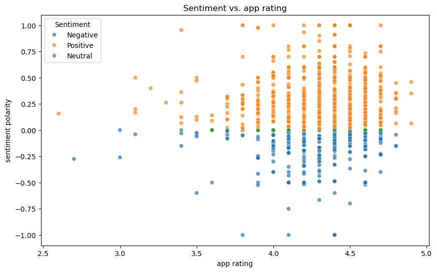

```python
#Visual 1 - FILL IN
import matplotlib.pyplot as plt
import seaborn as sns


plt.figure(figsize=(10, 6))
sns.scatterplot(data=combined_df, x='Rating', y='Sentiment_Polarity', hue='Sentiment', alpha=0.7)
plt.title('Sentiment vs. app rating')
plt.xlabel('app rating')
plt.ylabel('sentiment polarity')
plt.show()
```

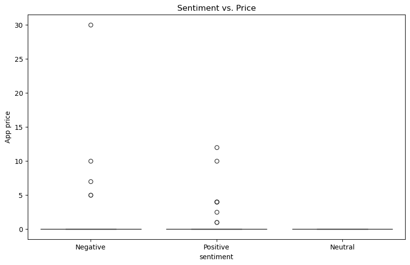

```python
#Visual 2 - FILL IN

plt.figure(figsize=(10, 6))
sns.boxplot(data=combined_df, x='Sentiment', y='Price')
plt.title('Sentiment vs. Price')
plt.xlabel('sentiment')
plt.ylabel('App price')
plt.show()
```

### **5.2:** Reflection

In 2-4 sentences, if you had more time to complete the project, what actions would you take? For example, which data quality and structural issues would you look into further, and what research questions would you further explore?

*Answer:* if i had more time to complete this project, i would focus on furhter improving the qulity of both sets. Probably by handeling the missing values in otherways than dropping them. i would also explore and analyze more relationships that ties the variables together and effects the product(app)

### This is a 3rd data set loaded by accseing API.

thid is done upon the reviewer suggestion to load a 3rd dataset using a second gathering method and solving a tidiness issue that it has

this dataset is about the reviews given by netfllix users from kaggle

# in this cell i will be showing a bit of code on how i accessed the file

mkdir -p ~/.kaggle

mv /Users/raghadhasan/Downloads/kaggle.json ~/.kaggle/

chmod 600 ~/.kaggle/kaggle.json

kaggle datasets download -d ashishkumarak/netflix-reviews-playstore-daily-updated

```python
import zipfile
import os


zip_path = '/Users/raghadhasan/netflix-reviews-playstore-daily-updated.zip'
extract_to = '/Users/raghadhasan/netflix_reviews'

with zipfile.ZipFile(zip_path, 'r') as zip_ref:
    zip_ref.extractall(extract_to)

files = os.listdir(extract_to)
print("Extracted files:", files)

csv_files = [f for f in files if f.endswith('.csv')]
if csv_files:
    df3 = pd.read_csv(os.path.join(extract_to, csv_files[0]))
    print(df3.head())
else:
    print("No CSV files found.")
```

```
Extracted files: ['netflix_reviews.csv']
                               reviewId       userName  \
0  9577e981-7e64-43dc-b933-72ea47765432    Zerrin Uzun
1  602535a4-e6df-4be1-9b7d-ec5a99698df8  **WoW Vɪᴊᴀʏ**
2  1059ee18-b56d-446a-ae93-900693f338ba  GamingNacho45
3  c4cd5ee5-14c5-4005-865c-83fcadbbf050  Janae Carruth
4  a57c653f-ee5b-449e-a0d7-f4a0d55c4533    Jason Byrne

                                             content  score  thumbsUpCount  \
0                                          Sevimabla      5              0
1                                           not sure      5              0
2           cannot uninstall, thus terrible app lmao      1              0
3  I've uninstalled reinstall looked up tutorial ...      1              0
4               excellent performance 👏 10 out of 10      5              0

   reviewCreatedVersion                   at            appVersion
0  9.12.0 build 5 62504  2025-05-01 13:28:12  9.12.0 build 5 62504
1  9.13.0 build 5 62532  2025-05-01 13:23:31  9.13.0 build 5 62532
2                   NaN  2025-05-01 13:16:09                   NaN
3  9.13.0 build 5 62532  2025-05-01 13:06:18  9.13.0 build 5 62532
4  9.13.0 build 5 62532  2025-05-01 12:32:56  9.13.0 build 5 62532
```

```python
df3.head()
```

|  | reviewId | userName | content | score | thumbsUpCount | reviewCreatedVersion | at | appVersion |
| --- | --- | --- | --- | --- | --- | --- | --- | --- |
| 0 | 9577e981-7e64-43dc-b933-72ea47765432 | Zerrin Uzun | Sevimabla | 5 | 0 | 9.12.0 build 5 62504 | 2025-05-01 13:28:12 | 9.12.0 build 5 62504 |
| 1 | 602535a4-e6df-4be1-9b7d-ec5a99698df8 | **WoW Vɪᴊᴀʏ** | not sure | 5 | 0 | 9.13.0 build 5 62532 | 2025-05-01 13:23:31 | 9.13.0 build 5 62532 |
| 2 | 1059ee18-b56d-446a-ae93-900693f338ba | GamingNacho45 | cannot uninstall, thus terrible app lmao | 1 | 0 | NaN | 2025-05-01 13:16:09 | NaN |
| 3 | c4cd5ee5-14c5-4005-865c-83fcadbbf050 | Janae Carruth | I've uninstalled reinstall looked up tutorial ... | 1 | 0 | 9.13.0 build 5 62532 | 2025-05-01 13:06:18 | 9.13.0 build 5 62532 |
| 4 | a57c653f-ee5b-449e-a0d7-f4a0d55c4533 | Jason Byrne | excellent performance 👏 10 out of 10 | 5 | 0 | 9.13.0 build 5 62532 | 2025-05-01 12:32:56 | 9.13.0 build 5 62532 |

```python
df3.columns
```

```
Index(['reviewId', 'userName', 'content', 'score', 'thumbsUpCount',
       'reviewCreatedVersion', 'at', 'appVersion'],
      dtype='object')
```

the column 'at' as seen has two varibles stored which is considered a tidiness issue so i will work on it by creatin another column to store date and time separetly

```python
df3.describe()
```

|  | score | thumbsUpCount |
| --- | --- | --- |
| count | 135129.000000 | 135129.000000 |
| mean | 2.854598 | 8.962443 |
| std | 1.724727 | 93.814246 |
| min | 1.000000 | 0.000000 |
| 25% | 1.000000 | 0.000000 |
| 50% | 3.000000 | 0.000000 |
| 75% | 5.000000 | 1.000000 |
| max | 5.000000 | 8032.000000 |

```python
df3.info()
```

```
<class 'pandas.core.frame.DataFrame'>
RangeIndex: 135129 entries, 0 to 135128
Data columns (total 8 columns):
 #   Column                Non-Null Count   Dtype
---  ------                --------------   -----
 0   reviewId              135129 non-null  object
 1   userName              135127 non-null  object
 2   content               135123 non-null  object
 3   score                 135129 non-null  int64
 4   thumbsUpCount         135129 non-null  int64
 5   reviewCreatedVersion  112509 non-null  object
 6   at                    135129 non-null  object
 7   appVersion            112509 non-null  object
dtypes: int64(2), object(6)
memory usage: 8.2+ MB
```

```python
# cleaning
# first i will convert the ype of at column to datetime type
df3['at'] = pd.to_datetime(df3['at'])

# now seperate
df3['date'] = df3['at'].dt.date
df3['time'] = df3['at'].dt.time

df3.head(2)
```

|  | reviewId | userName | content | score | thumbsUpCount | reviewCreatedVersion | at | appVersion | date | time |
| --- | --- | --- | --- | --- | --- | --- | --- | --- | --- | --- |
| 0 | 9577e981-7e64-43dc-b933-72ea47765432 | Zerrin Uzun | Sevimabla | 5 | 0 | 9.12.0 build 5 62504 | 2025-05-01 13:28:12 | 9.12.0 build 5 62504 | 2025-05-01 | 13:28:12 |
| 1 | 602535a4-e6df-4be1-9b7d-ec5a99698df8 | **WoW Vɪᴊᴀʏ** | not sure | 5 | 0 | 9.13.0 build 5 62532 | 2025-05-01 13:23:31 | 9.13.0 build 5 62532 | 2025-05-01 | 13:23:31 |

```python
df3.shape
```

```
(135129, 10)
```

```python
# as shown above they are seeperated now but still the column at is there
# so i am going to drop it since it is no use now

df3= df3.drop(columns= 'at')

df3.head(1)
```

|  | reviewId | userName | content | score | thumbsUpCount | reviewCreatedVersion | appVersion | date | time |
| --- | --- | --- | --- | --- | --- | --- | --- | --- | --- |
| 0 | 9577e981-7e64-43dc-b933-72ea47765432 | Zerrin Uzun | Sevimabla | 5 | 0 | 9.12.0 build 5 62504 | 9.12.0 build 5 62504 | 2025-05-01 | 13:28:12 |

```python
# just in case you want to, i am going to address a qulaity issue in this set and clean it
df3.duplicated().sum()
```

```
287
```

```python
df3=df3.drop_duplicates()
```

```python
df3.duplicated().sum()
```

```
0
```

```python
df3.shape
```

```
(134842, 9)
```